# Lab 7: Rectangling and Webscraping

Author

Alex Ptacek

# Overview

This is a two part assignment. In the first part of the assignment you will practice rectangling on a dataset from the `repurrrsive` package. In the second part you will combine the `rvest` package along with functions and iteration to scrape data on foreign linked political action committees from the website [open secrets](https://www.opensecrets.org).

# Rectangling

**Problem 1:** Load the `repurrrsive` package to get access to the `got_chars` dataset. In section 23.4.2 of R4DS, there is code that extracts data from the `got_chars` list and converts it into a tibble with information on each character and a separate tibble which contains information on the titles held by each character. Perform similar operations to create separate tibbles containing the aliases, allegiances, books, and TV series of each Game of Thrones character.

```r
library(tidyverse)
library(repurrrsive)
library(robotstxt)
library(rvest)
library(janitor)
library(scales)
```

```r
got_df <- tibble(json = got_chars)

#Aliases Tibble
got_aliases <- got_df |>
                unnest_wider(json) |>
                select(id, name, aliases) |>
                unnest_longer(aliases) |>
                rename(alias = aliases) |>
                filter(alias != "")
got_aliases
```

```
# A tibble: 107 × 3
      id name             alias
   <int> <chr>            <chr>
 1  1022 Theon Greyjoy    Prince of Fools
 2  1022 Theon Greyjoy    Theon Turncloak
 3  1022 Theon Greyjoy    Reek
 4  1022 Theon Greyjoy    Theon Kinslayer
 5  1052 Tyrion Lannister The Imp
 6  1052 Tyrion Lannister Halfman
 7  1052 Tyrion Lannister The boyman
 8  1052 Tyrion Lannister Giant of Lannister
 9  1052 Tyrion Lannister Lord Tywin's Doom
10  1052 Tyrion Lannister Lord Tywin's Bane
# ℹ 97 more rows
```

```r
#Allegiances Tibble
got_allegiances <- got_df |>
                unnest_wider(json) |>
                select(id, name, allegiances) |>
                unnest_longer(allegiances) |>
                rename(allegiance = allegiances)
got_allegiances
```

```
# A tibble: 33 × 3
      id name               allegiance
   <int> <chr>              <chr>
 1  1022 Theon Greyjoy      House Greyjoy of Pyke
 2  1052 Tyrion Lannister   House Lannister of Casterly Rock
 3  1074 Victarion Greyjoy  House Greyjoy of Pyke
 4  1166 Areo Hotah         House Nymeros Martell of Sunspear
 5   130 Arianne Martell    House Nymeros Martell of Sunspear
 6  1303 Daenerys Targaryen House Targaryen of King's Landing
 7  1319 Davos Seaworth     House Baratheon of Dragonstone
 8  1319 Davos Seaworth     House Seaworth of Cape Wrath
 9   148 Arya Stark         House Stark of Winterfell
10   149 Arys Oakheart      House Oakheart of Old Oak
# ℹ 23 more rows
```

```r
#Books Tibble
got_books <- got_df |>
                unnest_wider(json) |>
                select(id, name, books) |>
                unnest_longer(books) |>
                rename(book = books)
got_books
```

```
# A tibble: 77 × 3
      id name              book
   <int> <chr>             <chr>
 1  1022 Theon Greyjoy     A Game of Thrones
 2  1022 Theon Greyjoy     A Storm of Swords
 3  1022 Theon Greyjoy     A Feast for Crows
 4  1052 Tyrion Lannister  A Feast for Crows
 5  1052 Tyrion Lannister  The World of Ice and Fire
 6  1074 Victarion Greyjoy A Game of Thrones
 7  1074 Victarion Greyjoy A Clash of Kings
 8  1074 Victarion Greyjoy A Storm of Swords
 9  1109 Will              A Clash of Kings
10  1166 Areo Hotah        A Game of Thrones
# ℹ 67 more rows
```

```r
#TV Series Tibble
got_tv_series <- got_df |>
                unnest_wider(json) |>
                select(id, name, tvSeries) |>
                unnest_longer(tvSeries) |>
                rename(tvseries = tvSeries) |>
                filter(tvseries != "")
got_tv_series
```

```
# A tibble: 93 × 3
      id name             tvseries
   <int> <chr>            <chr>
 1  1022 Theon Greyjoy    Season 1
 2  1022 Theon Greyjoy    Season 2
 3  1022 Theon Greyjoy    Season 3
 4  1022 Theon Greyjoy    Season 4
 5  1022 Theon Greyjoy    Season 5
 6  1022 Theon Greyjoy    Season 6
 7  1052 Tyrion Lannister Season 1
 8  1052 Tyrion Lannister Season 2
 9  1052 Tyrion Lannister Season 3
10  1052 Tyrion Lannister Season 4
# ℹ 83 more rows
```

# Webscraping Open Secrets

In this assignment we will scrape and work with data foreign connected PACs that donate to US political campaigns. In the United States, only American citizens and green card holders can contribute to federal elections, but the American divisions of foreign companies can form political action committees (PACs) and collect contributions from their American employees.

First, we will get data foreign connected PAC contributions in the 2022 election cycle. Then, you will use a similar approach to get data such contributions from previous years so that we can examine trends over time.

In order to complete this assignment you will need a Chrome browser with the [Selector Gadget extension](http://selectorgadget.com/) installed.

In addition to `tidyverse`, you will need to install and load the packages `robotstxt` and `rvest`

**Problem 2:**

- Check that open secrets allows you to webscrape by running the `paths_allowed` function on the url `https://www.opensecrets.org`.

```r
paths_allowed("https://www.opensecrets.org")
```

```
 www.opensecrets.org
```

```
[1] TRUE
```

- Write a function called `scrape_pac()` that scrapes information from the Open Secrets webpage for foreign connected PAC contributions in a given year. The `url` for this data is https://www.opensecrets.org/political-action-committees-pacs/foreign-connected-pacs/2024. This function should take the url of the webpage as its only input and should output a data frame. The variables of this data-frame should be renamed so that they are in `snake_case` format (`lower_case_and_underscores_for_spaces`, see R4DS section 2.3). Use `str_squish()` to remove excess whitespace from the Country of Origin/Parent Company variables, and add a new column which records the year by extracting from the input url.

Hint: If you have trouble finding the right elements to search for using the selector gadget try looking for a table element.

```r
#Function for scraping Open Secrets PAC contributions table
scrape_pac <- function(url) {
                html_pac <- read_html(url)

                html_pac |>
                  html_element(".DataTable-Partial") |>
                  html_table() |>
                  clean_names() |>
                  mutate(country_of_origin_parent_company =
                           str_squish(country_of_origin_parent_company)) |>
                  mutate(year = str_extract(url, "\\d{4}")) |>
                  relocate(year, .before = 1)
}
```

```r
pac_2024 <- scrape_pac("https://www.opensecrets.org/political-action-committees-pacs/foreign-connected-pacs/2024")
pac_2024 |> head(5)
```

```
# A tibble: 5 × 6
  year  pac_name_affiliate             country_of_origin_pa…¹ total dems  repubs
  <chr> <chr>                          <chr>                  <chr> <chr> <chr>
1 2024  Accenture (Accenture)          Ireland/Accenture plc  $38,… $18,… $20,5…
2 2024  Acreage Holdings               Canada/Acreage Holdin… $0    $0    $0
3 2024  Air Liquide America            France/L'Air Liquide … $21,… $3,5… $17,5…
4 2024  Airbus Group                   Netherlands/Airbus Gr… $266… $78,… $187,…
5 2024  Alexion Pharmaceuticals (Astr… UK/AstraZeneca PLC     $113… $59,… $54,0…
# ℹ abbreviated name: ¹country_of_origin_parent_company
```

```r
pac_2022 <- scrape_pac("https://www.opensecrets.org/political-action-committees-pacs/foreign-connected-pacs/2022")
pac_2022 |> head(5)
```

```
# A tibble: 5 × 6
  year  pac_name_affiliate             country_of_origin_pa…¹ total dems  repubs
  <chr> <chr>                          <chr>                  <chr> <chr> <chr>
1 2022  Accenture (Accenture)          Ireland/Accenture plc  $3,0… $0    $3,000
2 2022  Acreage Holdings               Canada/Acreage Holdin… $0    $0    $0
3 2022  Air Liquide America            France/L'Air Liquide … $17,… $14,… $2,500
4 2022  Airbus Group                   Netherlands/Airbus Gr… $193… $82,… $111,…
5 2022  Alexion Pharmaceuticals (Astr… UK/AstraZeneca PLC     $186… $104… $82,2…
# ℹ abbreviated name: ¹country_of_origin_parent_company
```

```r
pac_2020 <- scrape_pac("https://www.opensecrets.org/political-action-committees-pacs/foreign-connected-pacs/2020")
pac_2020 |> head(5)
```

```
# A tibble: 5 × 6
  year  pac_name_affiliate    country_of_origin_parent_comp…¹ total dems  repubs
  <chr> <chr>                 <chr>                           <chr> <chr> <chr>
1 2020  7-Eleven              Japan/Seven & I Holdings        $20,… $1,0… $19,0…
2 2020  ABB Group (ABB Group) Switzerland/Asea Brown Boveri   $16,… $6,8… $10,1…
3 2020  Accenture (Accenture) Ireland/Accenture plc           $83,… $50,… $33,0…
4 2020  Air Liquide America   France/L'Air Liquide SA         $37,… $15,… $22,0…
5 2020  Airbus Group          Netherlands/Airbus Group        $182… $79,… $103,…
# ℹ abbreviated name: ¹country_of_origin_parent_company
```

**Problem 3:**

- Construct a vector called `urls` that contains the URLs for each webpage that contains information on foreign-connected PAC contributions for a given year (combine `seq` and string functions). Using the `map_dfr` function from the `purrr` package, apply the `scrape_pac()` function over `urls` in a way that will result in a data frame called `pac_all` that contains the data for all of the years.

```r
base_pac_url <- "https://www.opensecrets.org/political-action-committees-pacs/foreign-connected-pacs/2000"

urls <- str_replace(base_pac_url, "\\d{4}", as.character(seq(2000, 2024, 2)))

pac_all <- urls |>
  map_dfr(scrape_pac)
```

- Clean this combined dataset by separating the country of origin from the parent company (use `separate_wider_delim` or another tool of your choice, you will need to be cautious with some special cases in this column) and by converting the strings in the `total`, `dems`, and `repubs` columns into numbers. Print out the top 10 rows over your dataset after completing these steps.

```r
pac_all <- pac_all |>
  separate_wider_delim(country_of_origin_parent_company,
                       delim = "/",
                       names = c("origin_country", "parent_company"),
                       too_many = "merge") |>
  mutate(across(total:repubs, \(x) str_remove_all(x, fixed("$"))),
         across(total:repubs, \(x) str_remove_all(x, ",")),
         across(total:repubs, \(x) parse_number(x)))
pac_all |> head(10)
```

```
# A tibble: 10 × 7
   year  pac_name_affiliate     origin_country parent_company total  dems repubs
   <chr> <chr>                  <chr>          <chr>          <dbl> <dbl>  <dbl>
 1 2000  7-Eleven               Japan          Ito-Yokado      8500  1500   7000
 2 2000  ABB Group              Switzerland    Asea Brown Bo… 46000 17000  28500
 3 2000  Accenture              UK             Accenture plc  75984 23000  52984
 4 2000  ACE INA                UK             ACE Group      38500 12500  26000
 5 2000  Acuson Corp (Siemens … Germany        Siemens AG      2000  2000      0
 6 2000  Adtranz (DaimlerChrys… Germany        DaimlerChrysl… 10500 10000    500
 7 2000  AE Staley Manufacturi… UK             Tate & Lyle    24000 10000  14000
 8 2000  AEGON USA (AEGON NV)   Netherlands    Aegon NV       58250 10500  47750
 9 2000  AIM Management Group   UK             AMVESCAP       25000 10000  15000
10 2000  Air Liquide America    France         L'Air Liquide…     0     0      0
```

- Calculate the total contributions from PACs linked to Canada and Mexico each year and plot how these contributions change over time.

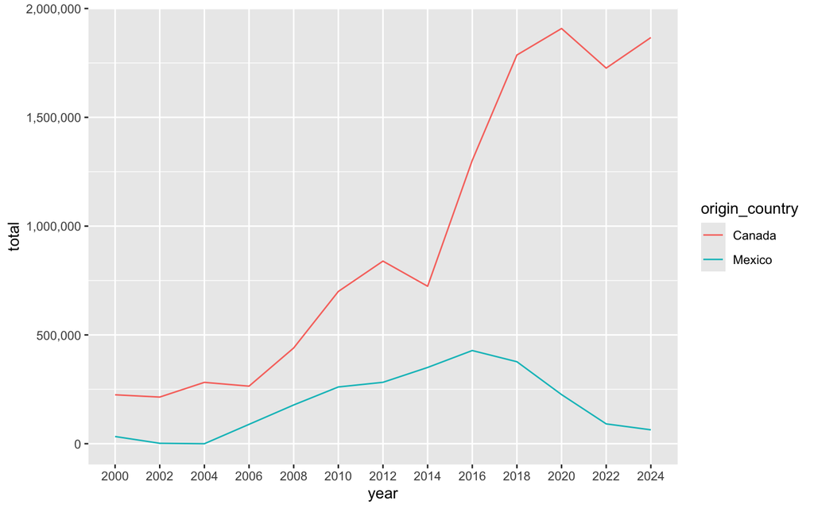

```r
pac_all |>
  group_by(year, origin_country) |>
  summarise(total = sum(total)) |>
  filter(origin_country == "Canada" |
         origin_country == "Mexico") |>

  ggplot(aes(x = year, y = total, group = origin_country, color = origin_country)) +
  geom_line() +
  scale_y_continuous(labels = comma)
```

- Find the 5 countries who over the entire time period of the dataset have the greatest total contribution from affiliated PACs. Then calculate the total contribution for each of those countries for each year of the data and make a plot of it to visualize how the contributions have changed over time.

```r
top_5_countries <- pac_all |>
            group_by(origin_country) |>
            summarise(total = sum(total)) |>
            arrange(desc(total)) |>
            head(5)
top_5_countries
```

```
# A tibble: 5 × 2
  origin_country    total
  <chr>             <dbl>
1 UK             60586064
2 Switzerland    36627569
3 Germany        28352614
4 Japan          18005447
5 Ireland        14499467
```

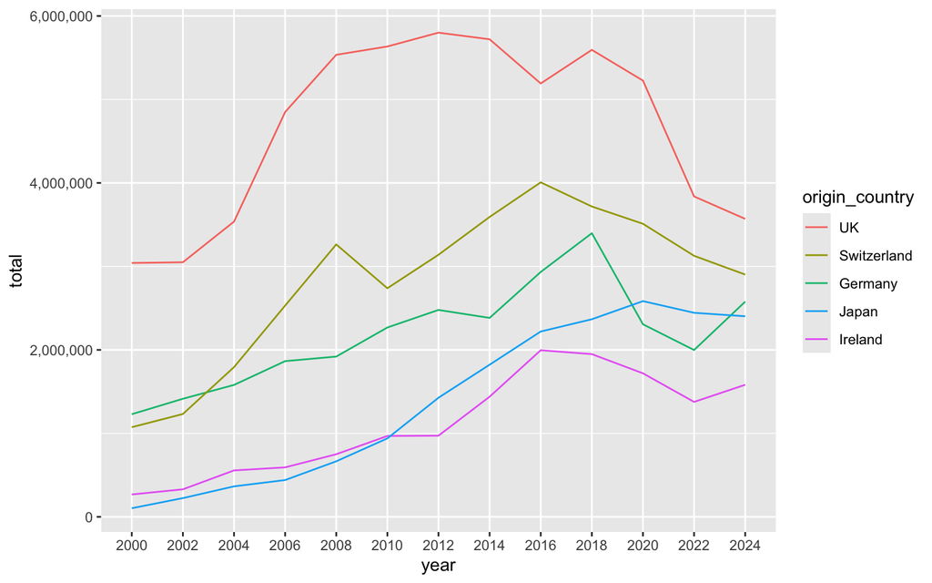

```r
pac_all |>
  filter(origin_country %in% top_5_countries$origin_country) |>
  group_by(year, origin_country) |>
  summarise(total = sum(total)) |>
  ggplot(aes(x = year, y = total,
             group = origin_country,
             color = fct_reorder2(origin_country, year, total))) +
  geom_line() +
  labs(color = "origin_country") +
  scale_y_continuous(labels = comma)
```